# Methods Tutorial: ERGM Specification

PLSC 508

- **Methods text:** Cranmer, Desmarais & Morgan, *Inferential Network Analysis*, Ch. 4 (pp. 67–97)
- **Replication data:** Metz & Brandenberger (2023), “Policy Networks Across Political Systems,” *AJPS* 67(3). Harvard Dataverse [doi:10.7910/DVN/NKCDCO](https://doi.org/10.7910/DVN/NKCDCO)
- **Networks:** directed collaboration ties among water-policy actors (micropollutants) in Switzerland (CH, n = 47), Germany (DE, 29), France (FR, 18), and the Netherlands (NL, 16)

Each code chunk is labeled as one of:

- **Replication**: reproduces something the paper or its replication script does.
- **Partial replication**: the paper does something similar, but we change the model, the measure, or the presentation.
- **Extension**: not in the paper; added for this tutorial.

### Background: consensus vs. majoritarian democracy

Lijphart distinguishes two visions of democracy by how they answer one question: *who governs when people disagree?*

- **Majoritarian democracy** concentrates power in the hands of the majority. A single party typically controls the cabinet, elections are first-past-the-post, the state is unitary, and interest groups compete with one another (pluralism). The winner governs and the loser waits for the next election. In policy networks, this predicts **concentrated power** and **limited contact with opponents**: decisions run through a few central actors, and competitors are kept out rather than bargained with.
- **Consensus democracy** spreads power across many actors. It has multi-party coalition cabinets, proportional representation, federalism, and corporatist arrangements that bring interest groups into policymaking. No single actor can decide alone, so agreement must be built. In policy networks, this predicts **diffused power** and **dense, cooperative ties that cross divides**, because institutions such as consultation procedures and working groups bring opponents into regular contact.

In this paper, Switzerland and Germany are consensual–federal, France is majoritarian–unitary, and the Netherlands is a consensual–unitary hybrid.

### Background: Advocacy Coalition Framework

Which beliefs bind a coalition?

| Belief layer | Content | Example in this paper | Shared within a coalition? | Expected effect of dissimilarity on collaboration |
| --- | --- | --- | --- | --- |
| **Deep core** | Fundamental values across all policy areas (left/right, role of the state) | Not measured | Not required | Weak or none |
| **Policy core** | Positions within one policy area: seriousness and causes of the problem, priority of values, basic strategy | Belief items: act at the source vs. end-of-pipe, precaution, wait for evidence, eliminate the substance | **Yes. Defines the coalition** | **Negative** (`edgecov(B)`) |
| **Secondary aspects** (instrumental beliefs) | Specific means: which tool, regulation, or budget | Instrument items: bans on single substances, discharge requirements | Not required; negotiable | Weaker (`edgecov(I)`) |

> **Note:** ACF predicts *coalitions*, but the paper’s outcome is *collaboration*, which also includes bargaining with opponents. Keep the ACF expectation in mind when reading the belief and instrument coefficients in Sections 2, 4a, and 5.

## The paper’s argument

Following Lijphart, political systems shape policy networks. Consensus democracies (CH, DE; NL as a hybrid) diffuse power and push actors to bargain with opponents. Majoritarian democracies (FR) concentrate power and exclude competitors.

### The networks

The authors surveyed 149 state and non-state actors involved in one policy issue, emerging pollutants in water (e.g., pharmaceuticals), in four countries. Actors include government bodies, political parties, scientific institutions, and water, environmental, and economic associations. Response rates were 89% (CH), 68% (DE), 51% (NL), and 46% (FR).

| Country | Policy process | Actors | Edges |
| --- | --- | --- | --- |
| Switzerland | Waters Protection Act and Ordinance amendment, 2007–13 | 47 | 241 |
| Germany | Surface Water Ordinance, 2008–11 | 29 | 116 |
| France | Micropollutants Plan, 2009–13 | 18 | 93 |
| Netherlands | Pharmaceutical pollutants policy process, 2001–13 | 16 | 108 |

### How edges were created

Each respondent received a complete list of the actors in its country and checked every organization it had “closely collaborated” with during the policy process. An edge **i → j** means i named j as a close collaboration partner.

- **Directed:** i naming j does not mean j named i, so reciprocity is modeled explicitly.
- **Binary:** 1 = named, 0 = not named; tie strength is not recorded.
- **Respondents only:** non-respondents were dropped, so only respondents appear as senders or receivers.
- **Self-nominations removed:** the paper’s counts (253, 121, 96, 108) include 12, 5, 3, and 0 self-ties, which are not valid dyads.

The same survey asked each actor to name **opponents** (actors it disagreed with on policy content) and to rate its **policy beliefs** and **instrument preferences** on 1–4 scales. These are not outcomes. They enter the model as covariates: the opponent matrix as `edgecov(O)`, and belief and instrument dissimilarity as `edgecov(B)` and `edgecov(I)`.

### Hypotheses

**H1 (Power).** Consensus systems diffuse power across several actors; majoritarian systems concentrate it in a few.

- Term: `gwidegree` (negative = in-degree concentrated = centralization)
- Expectation: stronger centralization in FR and NL (unitary systems)

**H2 (Interactions).** Consensus systems produce close-knit, cooperative ties, including across divides; majoritarian systems produce sparse, competitive ties. Three terms:

| Dimension | Term | Expectation |
| --- | --- | --- |
| Quantity | `gwesp` (triadic closure) | + in CH/DE, weaker in FR |
| Quality 1 | `edgecov(opponents)` | + in consensus systems |
| Quality 2 | `edgecov(belief dissimilarity)` | −, strongest in FR |

**Findings.** All four networks are centralized, more steeply in FR and NL (H1 supported). There is closure in CH, DE, and FR but not NL. Opponent ties are positive in CH and DE (weakly in NL) and null in FR. Belief dissimilarity matters only in FR. France is dense because opponents are excluded, not because of consensus-seeking.

## Setup

**Folder layout.** Download the Dataverse archive, unzip it, and place this `.Rmd` in the folder that contains `dataverse_files/`. Do not rename the folders. All paths below are relative to the `.Rmd`, so the tutorial runs on any machine with this layout, whether you knit or run chunks one at a time (in RStudio, set *Knit → Knit Directory → Document Directory*).

**Seeds.** Every step that draws random numbers (MCMC estimation, simulation, goodness of fit, network layouts) uses seed 123, so results are identical across runs and machines. If you change a chunk, delete the `_cache` folder before re-knitting.

**Versions.** The authors used network 1.16.1 and ergm 3.11.0. Under current versions, estimates differ slightly from the published tables (`SITAB4_ergms.tex`). `sessionInfo()` at the end records the versions used here.

**Replication.** We load the authors’ prepared data and their imputed attribute file, exactly as their script does.

```r
library(network); library(sna); library(ergm); library(btergm)
base <- "dataverse_files/ReplicationMaterials"                 # relative to this .Rmd
load(file.path(base, "0_Data/data_prepared.RData"))            # collabXX, oppXX, attXX, indegAll
load(file.path(base, "1_Analysis/output/attributeData.RData")) # attXX with imputed items appended
set.seed(123)
```

### Build networks and dyadic covariates

**Replication, adapted to current packages.** Newer versions of `network` read a data frame as an edgelist, so we convert to a matrix first. Belief and instrument dissimilarity are the mean absolute difference over survey items, giving the same values as the authors’ loops. Items are on 1–4 agreement scales, so values run from 0 to 3.

```r
make_nw <- function(collab, att) {
  m <- as.matrix(collab); diag(m) <- 0
  nw <- network(m, matrix.type = "adjacency", directed = TRUE)
  nw %v% "actorType"  <- as.character(att$actorTypesChar)
  nw %v% "repuTarget" <- att$reputation
  nw
}

dissim <- function(att, cols) {
  X <- as.matrix(att[, cols]); n <- nrow(X); M <- matrix(NA, n, n)
  for (i in 1:n) for (j in 1:n) {
    d <- abs(X[i, ] - X[j, ])
    M[i, j] <- if (all(is.na(d))) NA else mean(d, na.rm = TRUE)
  }
  M
}

nw  <- list(CH = make_nw(collabCH, attCH), DE = make_nw(collabDE, attDE),
            FR = make_nw(collabFR, attFR), NL = make_nw(collabNL, attNL))
opp <- lapply(list(CH = oppCH, DE = oppDE, FR = oppFR, NL = oppNL), as.matrix)
```

**Replication.** Columns 19:23 (beliefs) and 24:32 (instruments) are the **imputed** items appended in `attributeData.RData`, the same columns the authors use. The raw items are in columns 4:8 and 9:17.

```r
belief <- list(CH = dissim(attCH, 19:23), DE = dissim(attDE, 19:23),
               FR = dissim(attFR, 19:23), NL = dissim(attNL, 19:23))
instr  <- list(CH = dissim(attCH, 24:32), DE = dissim(attDE, 24:32),
               FR = dissim(attFR, 24:32), NL = dissim(attNL, 24:32))
```

### Checks

**Extension.** Sanity checks that the networks and covariates were built correctly.

```r
sapply(belief, function(m) sum(is.na(m)))     # edgecov needs no NAs
```

```
## CH DE FR NL
##  0  0  0  0
```

```r
sapply(nw, network.size)                      # 47, 29, 18, 16
```

```
## CH DE FR NL
## 47 29 18 16
```

```r
sapply(nw, network.edgecount)                 # 241, 116, 93, 108
```

```
##  CH  DE  FR  NL
## 241 116  93 108
```

**Extension.** The paper reports 253, 121, 96, and 108 edges. These equal our counts plus self-nominations on the diagonal (12, 5, 3, 0), which are not valid dyads and are dropped:

```r
sapply(list(CH = collabCH, DE = collabDE, FR = collabFR, NL = collabNL), function(m) {
  x <- suppressWarnings(matrix(as.numeric(as.matrix(m)), nrow(m)))
  sum(diag(x), na.rm = TRUE)
})
```

```
## CH DE FR NL
## 12  5  3  0
```

```r
lapply(nw, function(g) sort(unique(g %v% "actorType")))
```

```
## $CH
## [1] "env_NGO"           "industry_agri"     "national"
## [4] "party"             "regional"          "science"
## [7] "water_association"
##
## $DE
## [1] "env_NGO"           "industry_agri"     "national"
## [4] "regional"          "science"           "water_association"
##
## $FR
## [1] "env_NGO"           "national"          "regional"
## [4] "science"           "water_association"
##
## $NL
## [1] "env_NGO"           "industry_agri"     "national"
## [4] "regional"          "science"           "water_association"
```

**Replication.** The authors’ `base = -3` (ergm 3.11) keeps only the `"national"` level, which we now select by name. “National” means national government (ministry, parliament, bureaucracy). Regional and local government form a separate category, so the authors’ “governmental actors” term covers national government only.

```r
gov <- c(CH = "national", DE = "national", FR = "national", NL = "national")

## We work with Switzerland; Section 5 brings in the other three.
g <- nw$CH; O <- opp$CH; B <- belief$CH; I <- instr$CH; lv <- gov["CH"]
```

## 0. Descriptive overview

Before modeling, we look at what the four networks contain. Each item below sets up a later modeling choice.

### Network-level summary

**Partial replication.** The paper reports actors, edges, and density for each network. We add reciprocity, transitivity, centralization, and isolates.

- **Density:** share of possible directed ties present, edges / (n(n − 1)).
- **Reciprocity:** share of ties that are returned.
- **Transitivity:** share of two-paths i → j → k that are closed by i → k.
- **In-/out-degree centralization:** how unequally incoming/outgoing ties are spread (0 = all actors equal, 1 = one actor holds all ties).

```r
desc <- t(sapply(nw, function(x) c(
  actors         = network.size(x),
  edges          = network.edgecount(x),
  density        = round(sna::gden(x), 3),
  reciprocity    = unname(round(sna::grecip(x, measure = "edgewise"), 3)),
  transitivity   = round(sna::gtrans(x), 3),
  indeg_central  = round(sna::centralization(x, sna::degree, cmode = "indegree"), 3),
  outdeg_central = round(sna::centralization(x, sna::degree, cmode = "outdegree"), 3),
  isolates       = length(sna::isolates(x)),
  mean_outdegree = round(mean(sna::degree(x, cmode = "outdegree")), 2))))
desc
```

```
##    actors edges density reciprocity transitivity indeg_central outdeg_central
## CH     47   241   0.111       0.432        0.292         0.730          0.552
## DE     29   116   0.143       0.483        0.437         0.407          0.333
## FR     18    93   0.304       0.581        0.584         0.488          0.363
## NL     16   108   0.450       0.722        0.657         0.373          0.516
##    isolates mean_outdegree
## CH        1           5.13
## DE        3           4.00
## FR        0           5.17
## NL        1           6.75
```

> **What we see:** density rises from 11% (CH) to 45% (NL) because smaller networks are denser; reciprocity and transitivity rise with it. This is why Section 5 compares predicted probabilities rather than raw coefficients. Note that raw in-degree centralization is *highest* in Switzerland (0.73), the opposite of H1. The index depends on network size and density, so it cannot be compared across these networks. The ERGM’s `gwidegree` asks a different question: whether in-ties concentrate *more than expected given density, reciprocity, and closure*. That is where the H1 pattern appears (Section 5).

### Who is in each network?

**Extension.** Actor-type composition by country.

```r
types <- sort(unique(unlist(lapply(nw, function(x) x %v% "actorType"))))
sapply(nw, function(x) table(factor(x %v% "actorType", levels = types)))
```

```
##                   CH DE FR NL
## env_NGO            5  5  4  2
## industry_agri      7  7  0  2
## national          12  5  5  5
## party              5  0  0  0
## regional           6  6  2  1
## science            8  2  5  3
## water_association  4  4  2  3
```

### In-degree distributions

**Extension.** A skewed in-degree distribution (a few actors receive most nominations) is the pattern `gwidegree` models for H1.

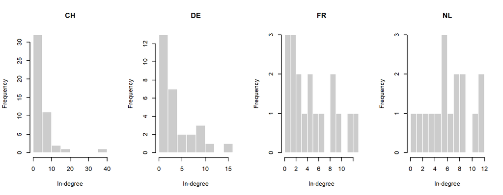

```r
par(mfrow = c(1, 4))
for (cc in names(nw)) {
  hist(sna::degree(nw[[cc]], cmode = "indegree"), breaks = 10,
       main = cc, xlab = "In-degree", col = "grey80", border = "white")
}
```

```r
par(mfrow = c(1, 1))
```

### The four networks

**Partial replication** of the paper’s Figure 1. Nodes are colored by actor type and sized by in-degree. Layouts are random, so we set the seed.

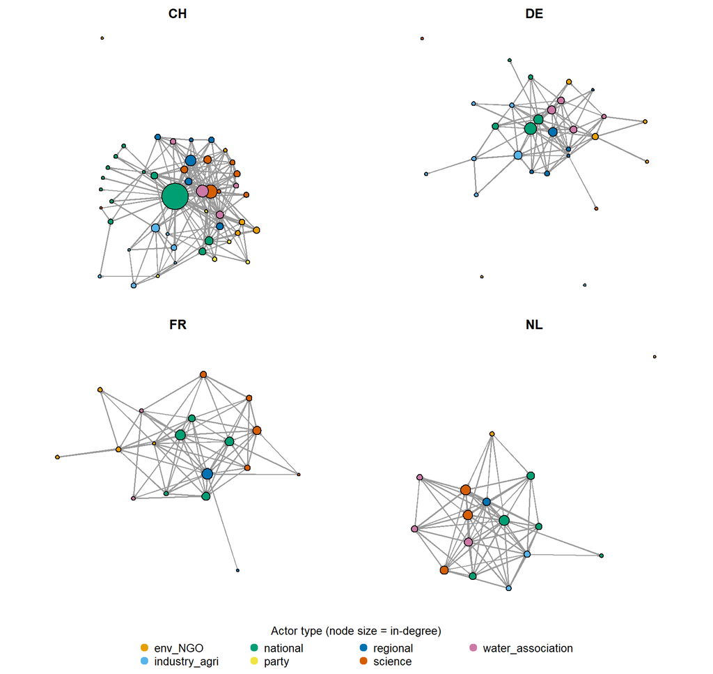

```r
set.seed(123)
pal <- setNames(c("#E69F00", "#56B4E9", "#009E73", "#F0E442",
                  "#0072B2", "#D55E00", "#CC79A7")[seq_along(types)], types)

par(mfrow = c(2, 2), mar = c(1, 1, 2, 1), oma = c(4, 0, 0, 0))   # room at the bottom
for (cc in names(nw)) {
  x <- nw[[cc]]
  plot(x, vertex.col = pal[x %v% "actorType"],
       vertex.cex = 0.5 + sna::degree(x, cmode = "indegree") / 8,
       arrowhead.cex = 0.4, edge.col = "grey60", main = cc)
}

## One shared legend across the bottom of the figure
par(fig = c(0, 1, 0, 1), oma = c(0, 0, 0, 0), mar = c(0, 0, 0, 0), new = TRUE)
plot(0, 0, type = "n", bty = "n", xaxt = "n", yaxt = "n")
legend("bottom", legend = types, col = pal, pch = 19, pt.cex = 1.5,
       ncol = 4, bty = "n", xpd = TRUE, title = "Actor type (node size = in-degree)")
```

```r
par(mfrow = c(1, 1))
```

### The opponent network

**Extension.** How many opponents are named, and how often an opponent is also a collaboration partner. This is the raw pattern behind `edgecov(O)`.

```r
t(sapply(names(nw), function(cc) {
  m <- as.matrix(nw[[cc]]); o <- opp[[cc]]; diag(o) <- 0
  c(opponent_ties        = sum(o == 1),
    also_collaboration   = sum(o == 1 & m == 1),
    share_collab_if_opp  = round(mean(m[o == 1]), 3),
    share_collab_if_not  = round(mean(m[o == 0 & row(m) != col(m)]), 3))
}))
```

```
##    opponent_ties also_collaboration share_collab_if_opp share_collab_if_not
## CH            57                 22               0.386               0.104
## DE            70                 33               0.471               0.112
## FR            14                  8               0.571               0.291
## NL            46                 34               0.739               0.381
```

> **What we see:** in every country, actors collaborate more with those they name as opponents than with others. The jump is about ×4 in CH (0.39 vs. 0.10) and DE (0.47 vs. 0.11) but only about ×2 in FR and NL, where the dense small networks raise the baseline. France names only 14 opponents, so `edgecov(O)` has little variation there. Section 5 asks how much of this gap remains once other differences between the pairs are held fixed.

### Belief dissimilarity among tied and untied pairs

**Partial replication** of the paper’s Figure 6 (left panel), which shows tied pairs only. We add untied pairs for comparison.

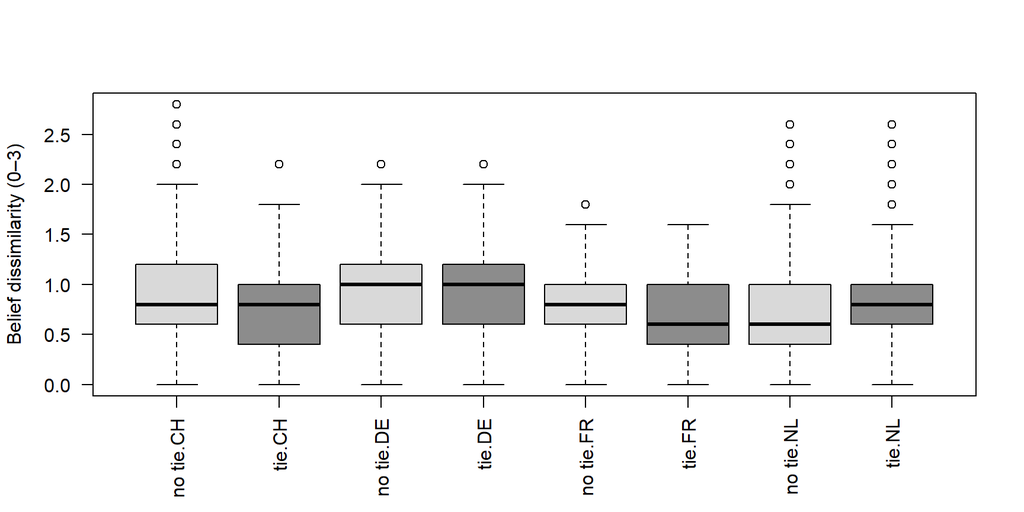

```r
bd <- do.call(rbind, lapply(names(nw), function(cc) {
  m <- as.matrix(nw[[cc]]); off <- row(m) != col(m)
  data.frame(country = cc, tie = ifelse(m[off] == 1, "tie", "no tie"),
             dissim = belief[[cc]][off])
}))
boxplot(dissim ~ tie + country, data = bd, las = 2, xlab = "",
        ylab = "Belief dissimilarity (0–3)", col = c("grey85", "grey55"))
```

```r
aggregate(dissim ~ country + tie, data = bd, FUN = function(v) round(mean(v), 2))
```

| country | tie | dissim |
| --- | --- | --- |
| CH | no tie | 0.89 |
| DE | no tie | 0.93 |
| FR | no tie | 0.75 |
| NL | no tie | 0.82 |
| CH | tie | 0.79 |
| DE | tie | 0.91 |
| FR | tie | 0.70 |
| NL | tie | 0.95 |

> **What we see:** tied pairs are slightly more similar in beliefs than untied pairs in CH (0.79 vs. 0.89) and FR (0.70 vs. 0.75), with almost no difference in DE (0.91 vs. 0.93), and the reverse in NL (0.95 vs. 0.82). France’s collaborators are the most belief-similar (0.70), as in the paper’s Figure 6. The raw gaps are small, so any belief effect has to emerge once structure is controlled.

### Reputation and in-degree

**Extension.** Reputation counts how often others named an actor “particularly important.” If it tracks collaboration in-degree closely, using it as a *receiver* effect (Section 2) is close to circular.

```r
sapply(nw, function(x) round(cor(x %v% "repuTarget", sna::degree(x, cmode = "indegree")), 2))
```

```
##   CH   DE   FR   NL
## 0.82 0.89 0.92 0.88
```

> **What we see:** correlations of 0.82–0.92. Reputation and collaboration in-degree are nearly the same measure, which is why `nodeicov(reputation)` in Section 2 fits “better for the wrong reason.”

## 1. Start with theory

**What this tests:** nothing yet. We translate each hypothesis into a network configuration and look at how often it occurs.

- H1 power concentration → in-stars / `gwidegree` (popularity)
- H2 close-knit interaction → transitive triples / `gwesp` (closure)
- H2 cooperative interaction → covariates (Section 2), not structure

**Extension.** The paper does not report configuration counts. `summary()` counts each configuration in the observed network; these counts are the statistics an ERGM can condition on:

- `edges`: number of ties.
- `mutual`: pairs tied in both directions (i → j and j → i).
- `istar(2)` / `ostar(2)`: pairs of ties received by (sent from) the same actor. Many in-2-stars mean some actors receive a lot of ties.
- `ttriple`: transitive triples, i → j, j → k, and i → k (“a partner’s partner is my partner,” with a direction of flow).
- `ctriple`: cyclic triples, i → j → k → i. Few cycles relative to transitive triples suggest a hierarchy.
- `gwidegree(1.4, fixed = TRUE)`: a geometrically weighted summary of the in-degree distribution. The decay (1.4) sets how quickly each additional incoming tie to the same actor stops counting; `fixed = TRUE` keeps it at 1.4 instead of estimating it.
- `gwesp(0.25, fixed = TRUE)`: geometrically weighted edgewise shared partners. For each tie i → j it counts the partners k with i → k → j (in a directed network, ergm’s default is this “outgoing two-path,” OTP). The first shared partner counts fully and each further one less, at a rate set by the decay (0.25).

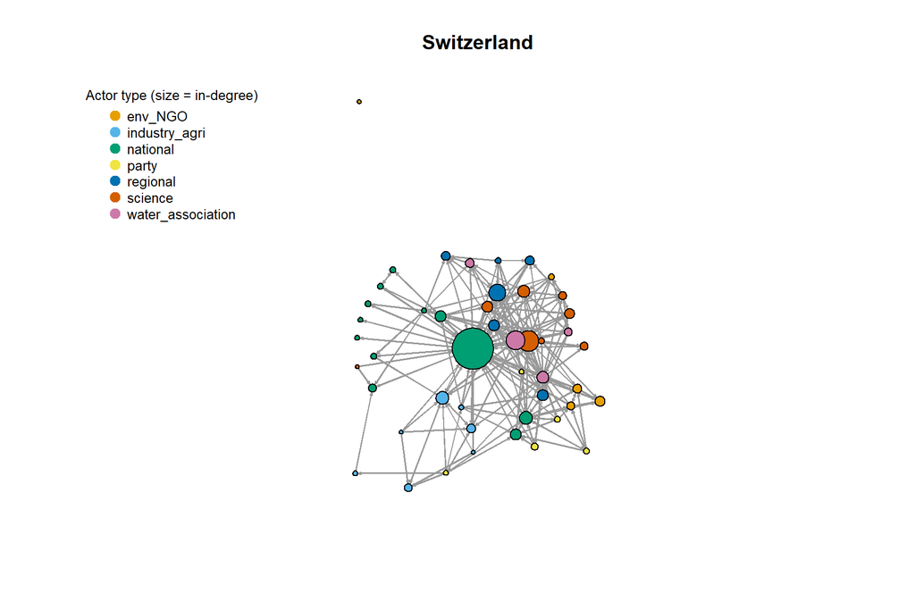

```r
set.seed(123)   # network layout is random
ch_types <- sort(unique(g %v% "actorType"))
plot(g, vertex.col = pal[g %v% "actorType"],
     vertex.cex = 0.5 + sna::degree(g, cmode = "indegree") / 8,
     arrowhead.cex = 0.5, edge.col = "grey60", main = "Switzerland")
legend("topleft", legend = ch_types, col = pal[ch_types], pch = 19, pt.cex = 1.3,
       bty = "n", cex = 0.8, title = "Actor type (size = in-degree)")
```

```r
summary(g ~ edges + mutual + istar(2) + ostar(2) + ttriple + ctriple +
          gwidegree(1.4, fixed = TRUE) + gwesp(0.25, fixed = TRUE))
```

```
##                edges               mutual               istar2
##             241.0000              52.0000            1383.0000
##               ostar2              ttriple              ctriple
##            1106.0000             619.0000             161.0000
##     gwideg.fixed.1.4 gwesp.OTP.fixed.0.25
##             111.8296             255.0892
```

> **In our run:** 241 edges, 52 mutual pairs, 619 transitive vs. 161 cyclic triples. Closure is hierarchical (transitive), not cyclic.

### Boundary specification: who is in the network?

**Extension.** The paper reports response rates; here we make the consequence for the network boundary explicit.

```r
table(indegAll$country, indegAll$missing)     # 1 = survey non-responder
```

```
##
##                0  1
##   France      18 14
##   Germany     29 10
##   Netherlands 16 10
##   Switzerland 47  5
```

Non-responders are dropped from the networks (CH 5, DE 10, FR 14, NL 10), not kept with missing out-ties. Dropped nodes change degree and closure counts, and response rates differ (89% in CH vs. 46% in FR).

## 2. Exogenous covariate effects

**What this tests:** H2 “quality” of interaction, before any network dependence is modeled (a plain logistic regression on dyads).

- `edgecov(O)`: do actors collaborate with those they name as opponents? H2 expects positive in consensus systems like CH.
- `edgecov(B)`: does belief dissimilarity reduce collaboration? H2 expects negative, but weaker in consensus systems.
- The other terms are controls: instrument preferences, national government, and reputation.

**Extension.** The paper does not report a covariate-only model. Every term here is **dyad-independent**: whether i → j forms does not depend on any other tie. The model is therefore an ordinary logistic regression on the 2,162 directed pairs, and ergm fits it without MCMC. Each coefficient is the change in the log-odds of a tie when its statistic rises by one, holding the other terms fixed.

- `edges`: the baseline log-odds of a tie, like a regression intercept.
- `edgecov(O)`: sums a dyadic covariate over tied pairs. O is 1 if i named j as an opponent, so the coefficient is the shift in log-odds for a tie to a named opponent.
- `edgecov(B)`, `edgecov(I)`: the same for belief and instrument dissimilarity (0–3). The coefficient is the shift in log-odds per scale point of average disagreement.
- `nodeofactor("actorType", levels = lv)`: counts out-ties sent by actors in the chosen category (national government). Positive = that category is more active (sociality).
- `nodeifactor("actorType", levels = lv)`: counts in-ties received by that category. Positive = more popular.
- `nodeocov("repuTarget")`: sums the sender’s reputation over all ties. Positive = high-reputation actors send more ties.
- `absdiff("repuTarget")`: sums |reputation_i − reputation_j| over ties. Negative = homophily (similar actors tie); positive = ties link actors of different reputation.

```r
m_exo <- ergm(g ~ edges +
                edgecov(O) +                        # i collaborates with j whom i names as opponent
                edgecov(B) +                        # belief dissimilarity (dyadic)
                edgecov(I) +                        # instrument-preference dissimilarity
                nodeofactor("actorType", levels = lv) +  # sociality: national gov.
                nodeifactor("actorType", levels = lv) +  # popularity: national gov.
                nodeocov("repuTarget") +            # reputed actors send more ties
                absdiff("repuTarget"))              # reputation difference
summary(m_exo)    # dyad-independent: logistic regression, no MCMC
```

```
## Call:
## ergm(formula = g ~ edges + edgecov(O) + edgecov(B) + edgecov(I) +
##     nodeofactor("actorType", levels = lv) + nodeifactor("actorType",
##     levels = lv) + nodeocov("repuTarget") + absdiff("repuTarget"))
##
## Maximum Likelihood Results:
##
##                                 Estimate Std. Error MCMC % z value Pr(>|z|)
## edges                          -1.933568   0.255675      0  -7.563  < 1e-04 ***
## edgecov.O                       1.702972   0.326114      0   5.222  < 1e-04 ***
## edgecov.B                      -0.155253   0.189563      0  -0.819  0.41278
## edgecov.I                      -1.509993   0.246320      0  -6.130  < 1e-04 ***
## nodeofactor.actorType.national -0.018978   0.168294      0  -0.113  0.91021
## nodeifactor.actorType.national  0.201105   0.162634      0   1.237  0.21625
## nodeocov.repuTarget             0.025678   0.007923      0   3.241  0.00119 **
## absdiff.repuTarget              0.071774   0.009111      0   7.878  < 1e-04 ***
## ---
## Signif. codes:  0 '***' 0.001 '**' 0.01 '*' 0.05 '.' 0.1 ' ' 1
##
##      Null Deviance: 2997  on 2162  degrees of freedom
##  Residual Deviance: 1303  on 2154  degrees of freedom
##
## AIC: 1319  BIC: 1364  (Smaller is better. MC Std. Err. = 0)
```

> **In our run:** opponents +1.70 (H2 supported for CH), belief dissimilarity null, instrument dissimilarity −1.51.

### Swap the reputation term: sociality vs. popularity

**Extension.** `nodeicov("repuTarget")` is the receiver-side version of `nodeocov`: it sums the *receiver’s* reputation over all ties. Positive = high-reputation actors receive more ties. The two terms ask different questions (activity vs. popularity), which is the distinction in Table 4.1 of Ch. 4.

```r
m_exo_i <- update(m_exo, . ~ . - nodeocov("repuTarget") + nodeicov("repuTarget"))
summary(m_exo_i)
```

```
## Call:
## ergm(formula = g ~ edges + edgecov(O) + edgecov(B) + edgecov(I) +
##     nodeofactor("actorType", levels = lv) + nodeifactor("actorType",
##     levels = lv) + absdiff("repuTarget") + nodeicov("repuTarget"))
##
## Maximum Likelihood Results:
##
##                                 Estimate Std. Error MCMC % z value Pr(>|z|)
## edges                          -2.492885   0.270870      0  -9.203   <1e-04 ***
## edgecov.O                       1.643565   0.345385      0   4.759   <1e-04 ***
## edgecov.B                      -0.073448   0.198749      0  -0.370    0.712
## edgecov.I                      -1.537364   0.259452      0  -5.925   <1e-04 ***
## nodeofactor.actorType.national  0.165725   0.172074      0   0.963    0.335
## nodeifactor.actorType.national  0.069220   0.172229      0   0.402    0.688
## absdiff.repuTarget              0.044783   0.010074      0   4.446   <1e-04 ***
## nodeicov.repuTarget             0.082785   0.008705      0   9.510   <1e-04 ***
## ---
## Signif. codes:  0 '***' 0.001 '**' 0.01 '*' 0.05 '.' 0.1 ' ' 1
##
##      Null Deviance: 2997  on 2162  degrees of freedom
##  Residual Deviance: 1212  on 2154  degrees of freedom
##
## AIC: 1228  BIC: 1273  (Smaller is better. MC Std. Err. = 0)
```

> **In our run:** BIC falls from 1364 to 1273, a better fit for the wrong reason. Reputation is the number of times other respondents named the actor “particularly important,” which is in-degree in a second nomination network. So `nodeicov(reputation)` partly measures in-degree itself.

**Discussion**

- Why might reputed actors *send* more collaboration ties (the authors’ choice)?
- Opponent ties are one-sided perceptions (i names j), not mutual opposition.
- Belief dissimilarity enters as `edgecov`. The coefficient is the change in log-odds per scale point of average disagreement, built on imputed items.

## 3. Endogenous effects: Markov terms and degeneracy

**What this tests:**

- **3a:** H1 with a Markov term. Does the in-2-star (popularity) show power concentration?
- **3b:** Method only. Why Markov specifications are risky: degeneracy.

### 3a. `istar(2)` in place of `gwidegree`

**Replication** of the authors’ Swiss robustness model (SI Table 5; `fit1CHb` in their script). This model adds two **dyad-dependent** terms, so whether one tie forms now depends on others, and ergm estimates by MCMC:

- `istar(2)` replaces `gwidegree`. It counts pairs of ties received by the same actor. Adding a tie to an actor who already has d in-ties raises the count by d, so a positive coefficient means ties flow to already-popular actors. Each extra in-tie counts at full weight, which is what makes Markov stars prone to degeneracy.
- `gwesp` and `mutual` (introduced in Section 1) enter as controls for closure and reciprocity.

```r
m_markov <- ergm(g ~ edges + edgecov(O) + gwesp(0.25, fixed = TRUE) + istar(2) +
                   edgecov(B) + edgecov(I) + mutual +
                   nodeofactor("actorType", levels = lv) +
                   nodeifactor("actorType", levels = lv) +
                   nodeocov("repuTarget") + absdiff("repuTarget"),
                 control = control.ergm(seed = 123))
summary(m_markov)
```

```
## Call:
## ergm(formula = g ~ edges + edgecov(O) + gwesp(0.25, fixed = TRUE) +
##     istar(2) + edgecov(B) + edgecov(I) + mutual + nodeofactor("actorType",
##     levels = lv) + nodeifactor("actorType", levels = lv) + nodeocov("repuTarget") +
##     absdiff("repuTarget"), control = control.ergm(seed = 123))
##
## Monte Carlo Maximum Likelihood Results:
##
##                                 Estimate Std. Error MCMC % z value Pr(>|z|)
## edges                          -3.529474   0.286753      0 -12.308   <1e-04 ***
## edgecov.O                       1.562008   0.348192      0   4.486   <1e-04 ***
## gwesp.OTP.fixed.0.25            1.010748   0.192571      0   5.249   <1e-04 ***
## istar2                          0.067651   0.012290      0   5.505   <1e-04 ***
## edgecov.B                      -0.089138   0.159657      0  -0.558   0.5766
## edgecov.I                      -0.978729   0.213543      0  -4.583   <1e-04 ***
## mutual                          1.186380   0.276256      0   4.295   <1e-04 ***
## nodeofactor.actorType.national -0.175387   0.171961      0  -1.020   0.3078
## nodeifactor.actorType.national -0.039443   0.133542      0  -0.295   0.7677
## nodeocov.repuTarget             0.019075   0.009620      0   1.983   0.0474 *
## absdiff.repuTarget              0.010431   0.009107      0   1.145   0.2520
## ---
## Signif. codes:  0 '***' 0.001 '**' 0.01 '*' 0.05 '.' 0.1 ' ' 1
##
##      Null Deviance: 2997  on 2162  degrees of freedom
##  Residual Deviance: 1113  on 2151  degrees of freedom
##
## AIC: 1135  BIC: 1198  (Smaller is better. MC Std. Err. = 0.5889)
```

> **In our run:** `istar2` = +0.068. Each additional incoming tie makes an actor more likely to receive the next one: popular actors attract more ties, consistent with power concentration (H1). For a Markov star, **positive** means centralization. Keep this in mind for Section 4. BIC = 1198.

### 3b. Degeneracy on this network

**Extension.** This model contains only Markov terms: edges, `mutual`, `istar(2)`, `ostar(2)`, and `ttriple`. We fit it by MPLE (maximum pseudo-likelihood), which treats each tie as a logistic regression *given the rest of the observed network*. MPLE only looks at small changes around the network we observed; it never checks what the model implies for networks far from it.

**Why this goes wrong.** Markov counts grow much faster than edges. Adding ties raises the number of 2-stars roughly with the square of each actor’s degree, and the number of triangles faster still. Near the observed 241 edges, a modest positive star or triangle coefficient looks harmless, balanced by the negative `edges` term. But once a few ties are added, the star and triangle counts outgrow the edge penalty, each new tie makes the next one more likely, and the network runs away to the complete graph. The estimates fit the observed network locally, yet the model they define puts nearly all its probability on the complete graph. This is **degeneracy**.

We show it two ways:

- **(a) Trace:** start a simulation at the observed network and follow the edge count, step by step. We compare the MPLE Markov model with the 3a model (also Markov stars, but estimated by MCMC with `gwesp` for closure), which stays near the observed network.
- **(b) Sensitivity:** nudge the `ttriple` coefficient upward and see where the simulated networks end up.

```r
m_mple <- ergm(g ~ edges + mutual + istar(2) + ostar(2) + ttriple,
               estimate = "MPLE")
round(coef(m_mple), 3)
```

```
##   edges  mutual  istar2  ostar2 ttriple
##  -4.566   1.095   0.100   0.088   0.240
```

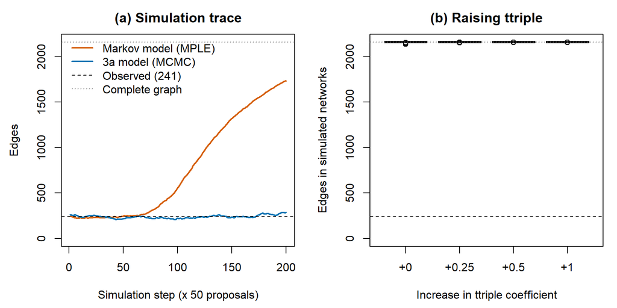

```r
## (a) Trace: start at the observed network, no burn-in, record the edge count
ctrl_trace <- control.simulate.ergm(MCMC.burnin = 0, MCMC.interval = 50)
tr_mple <- simulate(m_mple,   nsim = 200, output = "stats", seed = 123,
                    control = ctrl_trace)[, "edges"]
tr_3a   <- simulate(m_markov, nsim = 200, output = "stats", seed = 123,
                    control = ctrl_trace)[, "edges"]

## (b) Sensitivity: push the transitive-triple coefficient up
theta <- coef(m_mple)
bumps <- c(0, 0.25, 0.5, 1)
sim_edges <- sapply(bumps, function(bump) {
  th <- theta; th["ttriple"] <- th["ttriple"] + bump
  simulate(m_mple, coef = th, nsim = 50, output = "stats", seed = 123,
           control = control.simulate.ergm(MCMC.burnin = 20000))[, "edges"]
})
colnames(sim_edges) <- paste0("+", bumps)

n_dyads <- network.size(g) * (network.size(g) - 1)        # 2,162 possible ties
par(mfrow = c(1, 2), mar = c(4.5, 4.5, 2.5, 1))
plot(tr_mple, type = "l", lwd = 2, col = "#D55E00", ylim = c(0, n_dyads),
     xlab = "Simulation step (x 50 proposals)", ylab = "Edges",
     main = "(a) Simulation trace")
lines(tr_3a, lwd = 2, col = "#0072B2")
abline(h = network.edgecount(g), lty = 2)
abline(h = n_dyads, lty = 3, col = "grey50")
legend("topleft", bty = "n", lwd = c(2, 2, 1, 1), lty = c(1, 1, 2, 3),
       col = c("#D55E00", "#0072B2", "black", "grey50"),
       legend = c("Markov model (MPLE)", "3a model (MCMC)", "Observed (241)", "Complete graph"))
boxplot(sim_edges, ylim = c(0, n_dyads), col = "grey85",
        xlab = "Increase in ttriple coefficient", ylab = "Edges in simulated networks",
        main = "(b) Raising ttriple")
abline(h = network.edgecount(g), lty = 2)
abline(h = n_dyads, lty = 3, col = "grey50")
```

```r
par(mfrow = c(1, 1))
```

> **In our run:** the MPLE estimates are `edges` −4.57, `mutual` +1.10, `istar2` +0.10, `ostar2` +0.09, `ttriple` +0.24. Each star and triangle coefficient is small, but they apply to counts that grow much faster than edges.
> - **(a)** Starting from the observed network, the Markov model stays near 241 edges for about 60 steps, then takes off and passes 1,700 edges by step 200, still climbing toward the complete graph. The 3a model, estimated by MCMC, stays between about 200 and 300 throughout.
> - **(b)** Even with no change to the coefficients (+0), simulated networks are near-complete (about 2,160 of 2,162 edges). Raising `ttriple` changes nothing because there is nowhere left to go.

> The MPLE estimates describe the observed network locally, but the model they define puts almost all its probability on the complete graph. That is degeneracy.

## 4. Curved (GW) specification and goodness of fit

**What this tests:** H1 and H2 together, with network dependence modeled.

- `gwidegree` → H1 power concentration (expect negative)
- `gwesp` → H2 quantity: close-knit collaboration (expect + in CH)
- `edgecov(O)`, `edgecov(B)` → H2 quality, now net of structure

**Method points:** diagnostics, GOF on statistics outside the model, replication, decay choice, how to read the sign of a curved term, and choosing among specifications.

### 4a. Replicate the authors’ main model without interaction (SI Table 4)

**Replication** of the authors’ main Swiss model without interaction (SI Table 4; `fit1CH` in their script). We add a longer MCMC interval to reduce autocorrelation. The two curved terms replace their Markov counterparts:

- `gwidegree(1.4, fixed = TRUE)`: the curved version of in-stars. Each additional in-tie to the same actor adds less than the previous one, so the statistic cannot explode the way `istar(2)` can. **Sign:** negative = in-degree concentrated on a few actors (centralization, H1); positive = ties spread evenly. This is the opposite of `istar(2)` (see 4c).
- `gwesp(0.25, fixed = TRUE)`: the curved version of transitive triples. Positive = a tie is more likely when i and j already share partners (closure, H2 quantity). With a small decay such as 0.25, the first shared partner carries almost all the weight.
- `mutual`: number of reciprocated pairs. Positive = collaboration nominations tend to be returned.

The covariate terms keep their meaning from Section 2, but they are now estimated *net of* reciprocity, closure, and the in-degree distribution.

```r
fit1 <- ergm(g ~ edges + edgecov(O) +
               gwesp(0.25, fixed = TRUE) +            # H2 quantity: clustering
               gwidegree(1.4, fixed = TRUE) +         # H1: power concentration
               edgecov(B) + edgecov(I) + mutual +
               nodeofactor("actorType", levels = lv) +
               nodeifactor("actorType", levels = lv) +
               nodeocov("repuTarget") + absdiff("repuTarget"),
             control = control.ergm(seed = 123, MCMC.interval = 5000))
summary(fit1)
```

```
## Call:
## ergm(formula = g ~ edges + edgecov(O) + gwesp(0.25, fixed = TRUE) +
##     gwidegree(1.4, fixed = TRUE) + edgecov(B) + edgecov(I) +
##     mutual + nodeofactor("actorType", levels = lv) + nodeifactor("actorType",
##     levels = lv) + nodeocov("repuTarget") + absdiff("repuTarget"),
##     control = control.ergm(seed = 123, MCMC.interval = 5000))
##
## Monte Carlo Maximum Likelihood Results:
##
##                                 Estimate Std. Error MCMC % z value Pr(>|z|)
## edges                          -3.209914   0.305005      0 -10.524  < 1e-04 ***
## edgecov.O                       1.589652   0.333409      0   4.768  < 1e-04 ***
## gwesp.OTP.fixed.0.25            1.154169   0.184001      0   6.273  < 1e-04 ***
## gwideg.fixed.1.4               -1.093822   0.331463      0  -3.300 0.000967 ***
## edgecov.B                      -0.061745   0.140158      0  -0.441 0.659547
## edgecov.I                      -0.876660   0.193465      0  -4.531  < 1e-04 ***
## mutual                          1.203642   0.254426      0   4.731  < 1e-04 ***
## nodeofactor.actorType.national -0.111441   0.162634      0  -0.685 0.493201
## nodeifactor.actorType.national  0.071700   0.129940      0   0.552 0.581088
## nodeocov.repuTarget             0.013647   0.008435      0   1.618 0.105685
## absdiff.repuTarget              0.028614   0.008336      0   3.433 0.000597 ***
## ---
## Signif. codes:  0 '***' 0.001 '**' 0.01 '*' 0.05 '.' 0.1 ' ' 1
##
##      Null Deviance: 2997  on 2162  degrees of freedom
##  Residual Deviance: 1129  on 2151  degrees of freedom
##
## AIC: 1151  BIC: 1213  (Smaller is better. MC Std. Err. = 0.4588)
```

> **In our run:** `gwidegree` −1.09 (H1: centralized), `gwesp` +1.15 (H2: close-knit), opponents +1.59 (H2: cooperation across divides survives controlling for structure), belief dissimilarity null. BIC 1213. Instrument dissimilarity is strongly negative (−0.88) while belief dissimilarity is null: the reverse of the ACF expectation. Swiss actors collaborate across policy core divides, around shared solutions, which fits the paper’s consensus-democracy argument.

> **Compare with 3a:** the authors’ main model uses `gwidegree` instead of `istar(2)`. Its BIC is 1213 vs. 1198 for the in-2-star model, so the Markov term fits Switzerland better. The authors report the same in a footnote and run the in-2-star model as a robustness check because `gwidegree` fit the Swiss in-star distribution poorly. Note that the two terms carry opposite signs for the same pattern: `istar2` is positive, `gwidegree` is negative (see 4c).

**Extension.** The authors’ script includes `mcmc.diagnostics()` but does not report it.

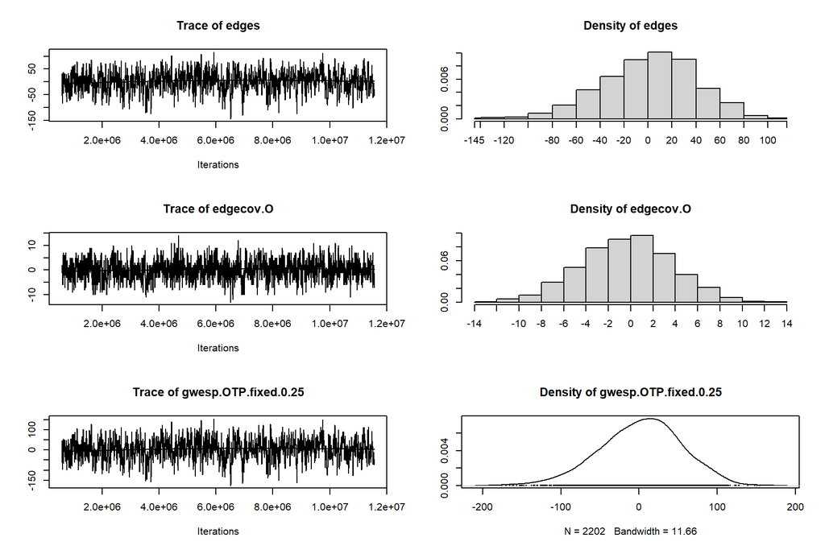

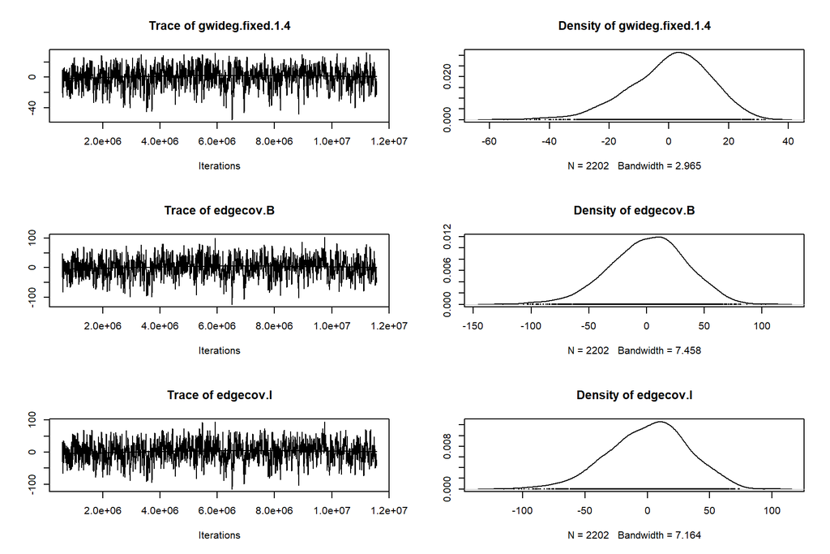

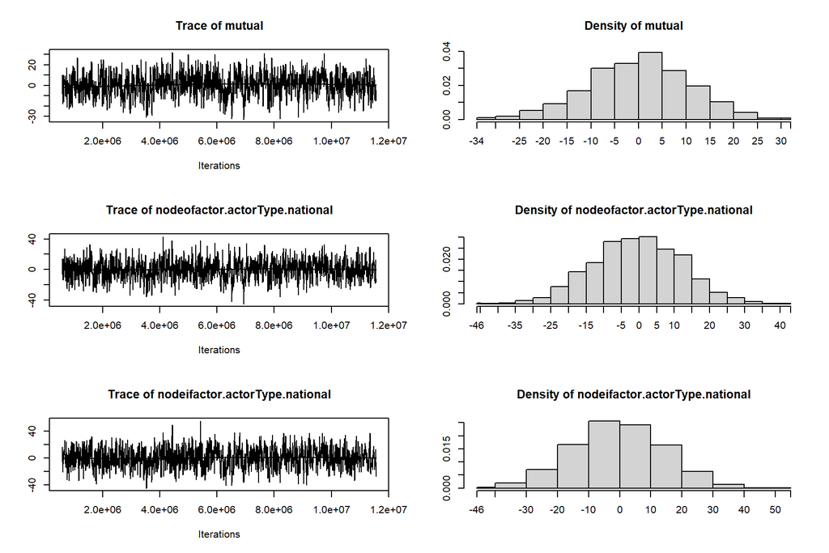

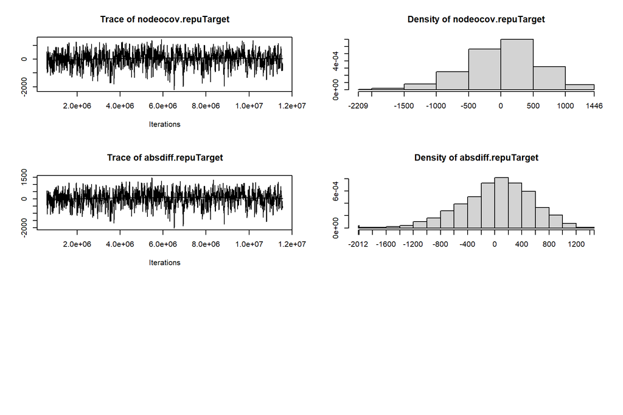

```
## Sample statistics summary:
##
## Iterations = 581568:11568960
## Thinning interval = 4992
## Number of chains = 1
## Sample size per chain = 2202
##
## 1. Empirical mean and standard deviation for each variable,
##    plus standard error of the mean:
##
##                                   Mean      SD Naive SE Time-series SE
## edges                           1.3597  39.365  0.83889         1.8573
## edgecov.O                       0.1076   4.032  0.08591         0.1365
## gwesp.OTP.fixed.0.25            2.1377  51.624  1.10013         2.4193
## gwideg.fixed.1.4                0.3894  13.380  0.28514         0.6037
## edgecov.B                       1.3014  32.864  0.70034         1.4992
## edgecov.I                       0.8838  31.757  0.67674         1.4581
## mutual                          0.3656  10.714  0.22831         0.4766
## nodeofactor.actorType.national -0.1231  12.521  0.26682         0.5120
## nodeifactor.actorType.national -0.1244  14.501  0.30902         0.5737
## nodeocov.repuTarget            17.3115 563.174 12.00146        26.6034
## absdiff.repuTarget             26.6517 517.777 11.03403        24.4586
##
## 2. Quantiles for each variable:
##
##                                    2.5%     25%    50%     75%   97.5%
## edges                            -80.00  -24.00  4.000  28.000   73.00
## edgecov.O                         -8.00   -3.00  0.000   3.000    8.00
## gwesp.OTP.fixed.0.25            -106.07  -31.31  4.722  37.409   97.87
## gwideg.fixed.1.4                 -28.21   -7.71  1.766   9.762   23.27
## edgecov.B                        -67.39  -20.15  2.800  23.800   61.00
## edgecov.I                        -65.65  -19.56  2.889  22.667   58.99
## mutual                           -21.00   -7.00  1.000   7.000   20.97
## nodeofactor.actorType.national   -24.00   -9.00  0.000   9.000   24.00
## nodeifactor.actorType.national   -28.97  -10.00  0.000  10.000   27.00
## nodeocov.repuTarget            -1177.88 -332.00 51.000 414.000 1038.00
## absdiff.repuTarget             -1071.57 -293.50 67.500 393.000  938.97
##
##
## Are sample statistics significantly different from observed?
```

[output cut: 133 more lines]

```
##             absdiff.repuTarget
##                      0.5577354
## Joint P-value (lower = worse):  0.4347266
##
## Note: To save space, only one in every 2 iterations of the MCMC sample
##   used for estimation was stored for diagnostics. Sample size per chain
##   was originally around 4404 with thinning interval 2496.
##
## Note: MCMC diagnostics shown here are from the last round of
##   simulation, prior to computation of final parameter estimates.
##   Because the final estimates are refinements of those used for this
##   simulation run, these diagnostics may understate model performance.
##   To directly assess the performance of the final model on in-model
##   statistics, please use the GOF command: gof(ergmFitObject,
##   GOF=~model).
```

```r
mcmc.diagnostics(fit1)
```

> **In our run:** autocorrelation at the first lag is about 0.64 with the longer MCMC interval (about 0.80 with ergm’s default), and Geweke tests pass (joint p = 0.43). The joint (Omni) test of simulated vs. observed statistics gives p = 0.004, though no single statistic differs (all p ≥ 0.28). These diagnostics come from the last MCMC round before the final estimates; the GOF below checks the final model.

**Partial replication.** The paper reports goodness of fit (Figure 2) using `btergm::gof(..., rocpr)` on the interaction model. We use ergm’s GOF on the model without interaction.

**Which statistics to check.** At the maximum likelihood estimate, the simulated networks reproduce the *model’s own* statistics by construction: the estimate is the value that makes their expected values equal the observed ones. So the real test is statistics the model was **not** fit to:

- **In-degree distribution:** how many actors receive 0, 1, 2, … nominations. This is the pattern H1 is about.
- **Out-degree distribution:** how many nominations each actor sends.
- **Edgewise shared partners:** for each tie, how many partners the two actors share. This checks closure.
- **Geodesic distances:** how many steps separate pairs of actors. This checks the network’s overall reach.

We run the same check on the in-2-star model from 3a. The authors report that `gwidegree` fits the Swiss in-degree distribution poorly and use the in-2-star model as a robustness check; the comparison shows whether that holds here. GOF simulates networks, so we set the seed.

```r
gof_aux <- ~ idegree + odegree + espartners + distance
gof_fit1 <- ergm::gof(fit1,     GOF = gof_aux, control = control.gof.ergm(seed = 123))
gof_3a   <- ergm::gof(m_markov, GOF = gof_aux, control = control.gof.ergm(seed = 123))

## Compact verdict: for each statistic, how many values fall outside the
## simulated range, and how many have MC p < 0.05
gof_check <- function(gf) {
  s <- gf[grep("^summary\\.(ideg|odeg|espart|dist)$", names(gf))]
  t(sapply(s, function(m) c(values        = nrow(m),
                            outside_range = sum(m[, "obs"] < m[, "min"] | m[, "obs"] > m[, "max"]),
                            p_below_05    = sum(m[, "MC p-value"] < 0.05, na.rm = TRUE))))
}
list(main_gwidegree = gof_check(gof_fit1), in2star_3a = gof_check(gof_3a))
```

```
## $main_gwidegree
##                values outside_range p_below_05
## summary.dist       47             0          0
## summary.espart     46             0          0
## summary.ideg       47             1          2
## summary.odeg       47             1          1
##
## $in2star_3a
##                values outside_range p_below_05
## summary.dist       47             0          0
## summary.espart     46             1          1
## summary.ideg       47             0          0
## summary.odeg       47             1          2
```

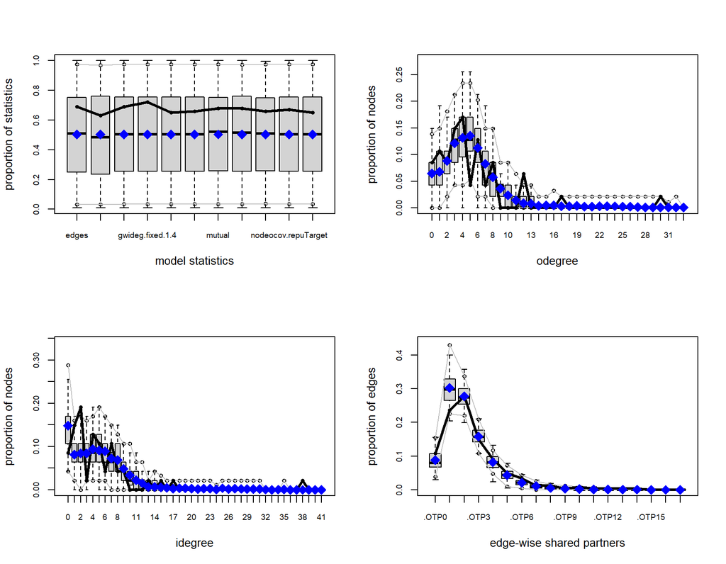

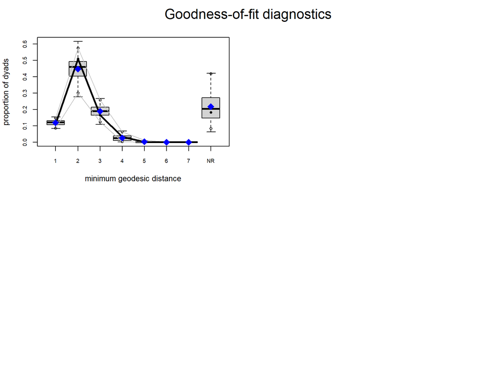

```r
## All auxiliary statistics for the main model
par(mfrow = c(2, 2)); ergm:::plot.gof(gof_fit1); par(mfrow = c(1, 1))
```

**In-degree, side by side.** Observed counts (black line) against the simulated mean (points) and range (grey bars), for both models.

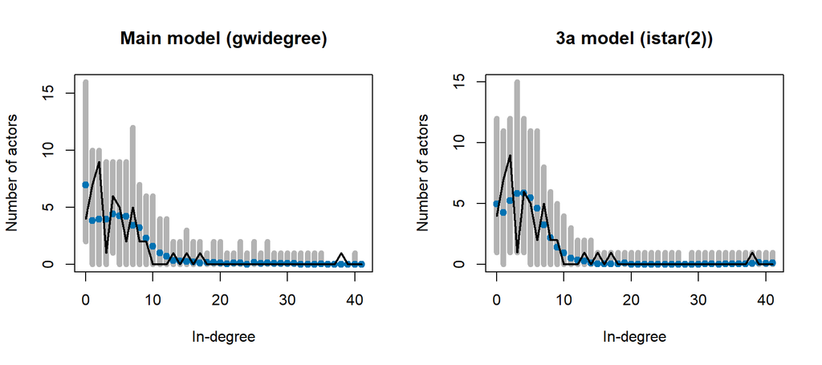

```r
plot_ideg <- function(gf, main) {
  m <- gf$summary.ideg
  k <- as.integer(rownames(m)); keep <- k <= max(k[m[, "obs"] > 0]) + 3
  m <- m[keep, , drop = FALSE]; k <- k[keep]
  plot(k, m[, "obs"], type = "n", ylim = range(m[, c("min", "max", "obs")]),
       xlab = "In-degree", ylab = "Number of actors", main = main)
  segments(k, m[, "min"], k, m[, "max"], col = "grey70", lwd = 6)
  points(k, m[, "mean"], pch = 19, col = "#0072B2")
  lines(k, m[, "obs"], lwd = 2)
}
par(mfrow = c(1, 2))
plot_ideg(gof_fit1, "Main model (gwidegree)")
plot_ideg(gof_3a,   "3a model (istar(2))")
```

```r
par(mfrow = c(1, 1))
```

> **In our run:** both models reproduce geodesic distances well, and the main model reproduces edgewise shared partners. The differences are in the degree distributions.
> - **In-degree (main model):** one value falls outside the simulated range and two have MC p < 0.05. The model expects too many actors that nobody names (about 7 vs. 4 observed) and too few with two nominations (about 4 vs. 9). It also rarely produces anything like the single hub named by 38 of the other 46 actors.
> - **In-degree (3a, `istar(2)`):** no values outside the range and no p < 0.05. Simulated counts track the observed distribution more closely, including the low end.
> - **Trade-off:** the in-2-star model fits in-degree better but loses a little on closure (one shared-partner value outside the range). Both models miss one very active sender in the out-degree distribution.
> - This matches the authors’ footnote: `gwidegree` fits the Swiss in-degree distribution poorly, which is why they report the in-2-star model as a robustness check. The H1 conclusion holds either way (both terms show concentration), but the curved term smooths over the hub structure.

> The “model statistics” panel in the first figure is the by-construction check described above; ergm adds it automatically.

**Extension.** Benchmark against the authors’ saved estimate (ergm 3.11.0):

```r
load(file.path(base, "1_Analysis/output/ERGM_estimates/fit1CH.RData"))
round(cbind(ours = coef(fit1), authors = coef(fit1CH)), 3)
```

```
##                                  ours authors
## edges                          -3.210  -3.184
## edgecov.O                       1.590   1.583
## gwesp.OTP.fixed.0.25            1.154   1.146
## gwideg.fixed.1.4               -1.094  -1.124
## edgecov.B                      -0.062  -0.050
## edgecov.I                      -0.877  -0.885
## mutual                          1.204   1.202
## nodeofactor.actorType.national -0.111  -0.115
## nodeifactor.actorType.national  0.072   0.067
## nodeocov.repuTarget             0.014   0.014
## absdiff.repuTarget              0.029   0.028
```

> **In our run:** every estimate is within 0.03 of the authors’ (largest gap: `gwidegree`, −1.094 vs. −1.124). Differences come from package versions and MCMC settings, not from the data or the model.

### 4b. Specification choices the authors fixed

We change one at a time. This tests whether the H1 and H2 conclusions depend on these choices. Every refit reuses `fit1`’s control settings, including seed 123.

- **Decay grid (partial replication):** the paper says the authors chose the `gwidegree` decay by comparing BIC across values but does not report the comparison. We refit `fit1` with decay 0.25, 0.5, 1, 1.4, 2, and 3, record each BIC and whether the fit converged, and plot BIC against decay. A lower decay discounts additional in-ties faster, so the term responds to whether actors have *any* in-ties more than to how many. The `gwidegree` coefficient itself changes with the decay, so its size can only be read together with the decay (Levy 2016). At large decays the term behaves like an in-2-star term.
- **`dgwdsp(0.25, fixed = TRUE, type = "OTP")` (extension):** geometrically weighted *dyadwise* shared partners. It counts shared partners for all pairs, tied or not. Including it with `gwesp` separates closure (shared partners on actual ties) from simply having many two-paths.

```r
## Decay grid for gwidegree (fit1 already uses 1.4; every refit reuses fit1's control, seed 123)
decays <- c(0.25, 0.5, 1, 1.4, 2, 3)
fit_decay <- function(d) {
  if (d == 1.4) return(fit1)
  tryCatch(update(fit1, as.formula(paste0(". ~ . - gwidegree(1.4, fixed = TRUE)",
                                          " + gwidegree(", d, ", fixed = TRUE)"))),
           error = function(e) NULL)
}
decay_fits <- lapply(decays, fit_decay)

decay_tab <- data.frame(
  decay     = decays,
  converged = !sapply(decay_fits, is.null),
  BIC       = sapply(decay_fits, function(f) if (is.null(f)) NA else round(BIC(f), 1)),
  gwideg    = sapply(decay_fits, function(f) if (is.null(f)) NA else
                round(coef(f)[grep("gwideg", names(coef(f)))], 2)),
  row.names = NULL)
decay_tab
```

| decay | converged | BIC | gwideg |
| --- | --- | --- | --- |
| 0.25 | TRUE | 1221.3 | -0.29 |
| 0.50 | TRUE | 1220.4 | -0.58 |
| 1.00 | TRUE | 1215.1 | -0.90 |
| 1.40 | TRUE | 1213.0 | -1.09 |
| 2.00 | TRUE | 1204.4 | -1.48 |
| 3.00 | TRUE | 1196.1 | -2.59 |

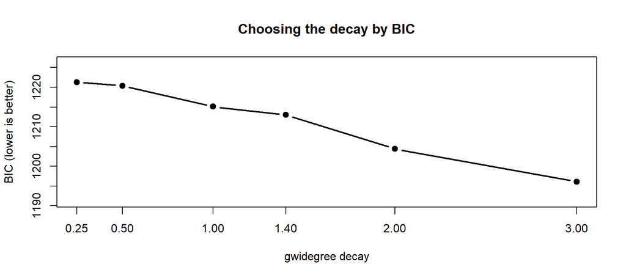

```r
ok <- decay_tab$converged
plot(decay_tab$decay[ok], decay_tab$BIC[ok], type = "b", pch = 19, lwd = 2,
     xlab = "gwidegree decay", ylab = "BIC (lower is better)", xaxt = "n",
     main = "Choosing the decay by BIC",
     ylim = range(decay_tab$BIC, na.rm = TRUE) + c(-5, 5))
axis(1, at = decays)
```

```r
if (any(!ok)) {
  points(decay_tab$decay[!ok], rep(par("usr")[3], sum(!ok)), pch = 4, cex = 2,
         col = "#D55E00", xpd = TRUE)
  legend("topright", pch = 4, col = "#D55E00", legend = "did not converge", bty = "n")
}
fit1_dec <- decay_fits[[which(decays == 0.5)]]    # kept for the summary table

## 2-path control (extension)
fit1_dsp <- tryCatch(update(fit1, . ~ . + dgwdsp(0.25, fixed = TRUE, type = "OTP")),
                     error = function(e) NULL)
is.null(fit1_dsp)                                  # TRUE = the dgwdsp model failed
```

```
## [1] TRUE
```

> **In our run:**
> - All six decay values converge. BIC falls steadily as the decay rises: 1221 (0.25), 1220 (0.5), 1215 (1), 1213 (1.4), 1204 (2), 1196 (3). The authors’ 1.4 is not the best value on this grid; 3 is better by 17 points, far beyond the Monte Carlo error of about 0.5.
> - Why: as the decay grows, `gwidegree` approaches *edges minus e^(−decay) × in-2-stars*. The edges part is absorbed by the `edges` term, so a large decay turns the curved term into a Markov in-2-star term. The implied in-2-star effect at decay 3 is about +0.13, the same sign and order as the +0.068 of model 3a, and the BIC (1196) is close to 3a’s (1198). The search has no interior minimum because the Swiss data, with one actor named by 38 others, keep pulling the term toward its Markov limit.
> - Why the authors still use 1.4: a decay chosen for Switzerland alone is not the goal. Their footnote reports that changing the decay made the DE, FR, and NL models degenerate. One specification must work in all four networks, so the decay is set by the smallest, densest networks.
> - The coefficient grows with the decay (−0.29 to −2.59) but stays negative throughout. Its size means nothing without its decay; its sign, and the H1 conclusion, hold for every value.
> - Adding the 2-path control (`dgwdsp`) made the sampler stop mixing: degeneracy from one extra term.

### Try it yourself

**Extension.** Two changes to `fit1`, one choice at a time. Because both are fitted to the same network, their BICs are directly comparable with `fit1`’s.

- **(a)** `edgecov(t(O))` uses opposition reported by the *receiver* (j named i as an opponent) instead of the sender. Does cooperation with opponents hold when we use the other side’s perception?
- **(b)** A larger `gwesp` decay (0.75 instead of 0.25) gives more weight to second and third shared partners, pushing the term back toward a Markov triangle count. **Expect this to fail** with “MCMC sampling did not mix”: the same degeneracy as Section 3b, and the reason the authors chose a small decay.

```r
## (a) Opposition named by the receiver (j names i) instead of the sender
alt_a <- update(fit1, . ~ . - edgecov(O) + edgecov(t(O)))
summary(alt_a)
```

```
## Call:
## ergm(formula = g ~ edges + gwesp(0.25, fixed = TRUE) + gwidegree(1.4,
##     fixed = TRUE) + edgecov(B) + edgecov(I) + mutual + nodeofactor("actorType",
##     levels = lv) + nodeifactor("actorType", levels = lv) + nodeocov("repuTarget") +
##     absdiff("repuTarget") + edgecov(t(O)), control = control.ergm(seed = 123,
##     MCMC.interval = 5000))
##
## Monte Carlo Maximum Likelihood Results:
##
##                                 Estimate Std. Error MCMC % z value Pr(>|z|)
## edges                          -3.396436   0.310062      0 -10.954  < 1e-04 ***
## gwesp.OTP.fixed.0.25            1.171325   0.191658      0   6.112  < 1e-04 ***
## gwideg.fixed.1.4               -1.058419   0.342781      0  -3.088 0.002017 **
## edgecov.B                       0.019270   0.138825      0   0.139 0.889602
## edgecov.I                      -0.756950   0.187026      0  -4.047  < 1e-04 ***
## mutual                          1.218463   0.258248      0   4.718  < 1e-04 ***
## nodeofactor.actorType.national -0.152029   0.159780      0  -0.951 0.341358
## nodeifactor.actorType.national  0.116252   0.124106      0   0.937 0.348905
## nodeocov.repuTarget             0.013621   0.008433      0   1.615 0.106255
## absdiff.repuTarget              0.031092   0.008004      0   3.884 0.000103 ***
## edgecov.t(O)                    0.693128   0.357572      0   1.938 0.052571 .
## ---
## Signif. codes:  0 '***' 0.001 '**' 0.01 '*' 0.05 '.' 0.1 ' ' 1
##
##      Null Deviance: 2997  on 2162  degrees of freedom
##  Residual Deviance: 1145  on 2151  degrees of freedom
##
## AIC: 1167  BIC: 1230  (Smaller is better. MC Std. Err. = 0.594)
```

```r
c(fit1 = BIC(fit1), receiver_opp = BIC(alt_a))
```

```
##         fit1 receiver_opp
##     1213.024     1229.562
```

```r
## (b) Larger closure decay
## >>> COMMENT OUT BEFORE KNITTING <<<  Fails (degeneracy); run it live in class.
# alt_b <- update(fit1, . ~ . - gwesp(0.25, fixed = TRUE) + gwesp(0.75, fixed = TRUE))
```

> **In our run:** with opposition reported by the receiver, the opponent effect falls from +1.59 to +0.69 (p = 0.053), and BIC rises from 1213 to 1230. Actors collaborate with those *they* call opponents much more than with those who call *them* opponents. So the “cooperation across divides” finding rests largely on one-sided perception. The structural terms barely move (`gwidegree` −1.06, `gwesp` +1.17), so H1 and closure are robust to this choice.

### 4c. What does the `gwidegree` sign mean?

**Extension.** Simulate from the fitted model with the `gwidegree` coefficient set to its negative and positive values. This tests the interpretation behind H1: does a negative coefficient mean concentration? `sna::centralization()` measures how unequally in-ties are spread (0 = equal, 1 = one actor receives all).

```r
k <- grep("gwideg", names(coef(fit1)))
for (b in c(-abs(coef(fit1)[k]), abs(coef(fit1)[k]))) {
  th <- coef(fit1); th[k] <- b
  s <- simulate(fit1, coef = th, nsim = 20, seed = 123)
  cent <- sapply(s, function(x) sna::centralization(x, sna::degree, cmode = "indegree"))
  cat("gwidegree =", round(b, 2), "| mean edges:", round(mean(sapply(s, network.edgecount))),
      "| mean in-degree centralization:", round(mean(cent), 3), "\n")
}
```

```
## gwidegree = -1.09 | mean edges: 262 | mean in-degree centralization: 0.481
## gwidegree = 1.09 | mean edges: 481 | mean in-degree centralization: 0.368
```

> **In our run:** the negative value gives higher in-degree centralization (0.48 vs. 0.37), even though the positive value produces almost twice as many edges (481 vs. 262). Negative means concentration, which confirms the authors’ reading (citing Levy 2016). Contrast with `istar2` in 3a, where positive means centralization.

### 4d. Specification summary

**Extension.** Every Swiss model in this tutorial, side by side. All are fitted to the same network, so their BICs are comparable; for MCMC models BIC is approximate (Monte Carlo error about 0.5), so differences of a point or two mean nothing. The GOF columns use the statistics *outside* the model (in-degree, out-degree, edgewise shared partners, geodesic distances), as in 4a: `outside_range` counts observed values outside the simulated range, `p_below_05` counts values with MC p < 0.05, and `misfit` lists the statistics where either occurs.

```r
gof_brief <- function(f, gf = NULL) {
  if (is.null(f)) return(list(outside = NA, p05 = NA, misfit = "—"))
  if (is.null(gf)) gf <- ergm::gof(f, GOF = gof_aux, control = control.gof.ergm(seed = 123))
  ch  <- gof_check(gf)
  bad <- sub("summary\\.", "", rownames(ch)[ch[, "outside_range"] > 0 | ch[, "p_below_05"] > 0])
  list(outside = sum(ch[, "outside_range"]), p05 = sum(ch[, "p_below_05"]),
       misfit = if (length(bad)) paste(bad, collapse = ", ") else "none")
}

specs <- list(
  "Covariates only (2)"              = list(m_exo,    NULL),
  "Reputation as receiver (2)"       = list(m_exo_i,  NULL),
  "In-2-star (3a)"                   = list(m_markov, gof_3a),
  "Main: gwidegree 1.4 (4a)"         = list(fit1,     gof_fit1),
  "gwidegree decay 0.5 (4b)"         = list(decay_fits[[which(decays == 0.5)]], NULL),
  "gwidegree decay 2 (4b)"           = list(decay_fits[[which(decays == 2)]],   NULL),
  "gwidegree decay 3 (4b)"           = list(decay_fits[[which(decays == 3)]],   NULL),
  "+ dgwdsp 2-path control (4b)"     = list(fit1_dsp, NULL),
  "Receiver-reported opponents"      = list(alt_a,    NULL))

spec_tab <- do.call(rbind, lapply(names(specs), function(nm) {
  f <- specs[[nm]][[1]]; gb <- gof_brief(f, specs[[nm]][[2]])
  data.frame(model         = nm,
             converged     = !is.null(f),
             BIC           = if (is.null(f)) NA else round(BIC(f), 1),
             outside_range = gb$outside,
             p_below_05    = gb$p05,
             misfit        = gb$misfit,
             row.names = NULL)
}))
spec_tab[order(spec_tab$BIC), ]
```

|  | model | converged | BIC | outside_range | p_below_05 | misfit |
| --- | --- | --- | --- | --- | --- | --- |
| 7 | gwidegree decay 3 (4b) | TRUE | 1196.1 | 0 | 1 | odeg |
| 3 | In-2-star (3a) | TRUE | 1197.5 | 2 | 3 | espart, odeg |
| 6 | gwidegree decay 2 (4b) | TRUE | 1204.4 | 2 | 3 | ideg, odeg |
| 4 | Main: gwidegree 1.4 (4a) | TRUE | 1213.0 | 2 | 3 | ideg, odeg |
| 5 | gwidegree decay 0.5 (4b) | TRUE | 1220.4 | 3 | 5 | espart, ideg, odeg |
| 9 | Receiver-reported opponents | TRUE | 1229.6 | 2 | 3 | ideg, odeg |
| 2 | Reputation as receiver (2) | TRUE | 1273.3 | 21 | 26 | dist, espart, ideg, odeg |
| 1 | Covariates only (2) | TRUE | 1364.1 | 21 | 27 | dist, espart, ideg, odeg |
| 8 | + dgwdsp 2-path control (4b) | FALSE | NA | NA | NA | — |

> **In our run:**
> - Covariate-only models (Section 2): BIC 1364 and 1273, 21 auxiliary values outside the simulated range. Without network terms the model cannot reproduce the structure.
> - Models with network terms: BIC 1196–1230; 0–3 values outside the range.
> - `gwidegree` decay 3: lowest BIC (1196.1), no values outside the range, one with p < 0.05 (out-degree). Best on both counts. The out-degree misfit (one very active sender) appears in every model.
> - In-2-star (3a): BIC 1197.5, about 1.4 points from decay 3. Same model in practice (see 4b): a large decay turns `gwidegree` into an in-2-star term.
> - Main model, decay 1.4: BIC 1213, in-degree misfit (4a).
> - Decay 0.5: worst structural model (BIC 1220, 3 outside, 5 with p < 0.05); misses shared partners as well as degree.
> - Receiver-reported opponents: BIC 1230. Structure fits as well as the main model; the opponent term explains less.
> - `dgwdsp`: did not converge. Not a candidate.

**Which specification?**

- **Switzerland alone:** `gwidegree` with decay 3, or `istar(2)`. The two are indistinguishable on BIC and GOF. Both capture the hub (one actor named by 38 of 46) better than decay 1.4.
- **Four-country comparison:** keep the authors’ decay 1.4. The paper’s claim needs one specification in every network. Other decays made the DE, FR, and NL models degenerate (authors’ footnote), and Markov stars run away on small, dense networks (3b).
- **Cost of that choice:** a worse fit for Switzerland, mainly in the in-degree distribution.
- **What does not change:** `gwidegree` is negative at every decay and `istar2` is positive. Both mean concentration, so H1 holds whichever specification we pick.
- **Lesson:** the best fit for one network and the best specification for a comparison are not the same thing. Report both, and say which one carries the argument.

## 5. One specification, four political systems

**What this tests:** the comparative claim. Do the H1 and H2 effects differ by political system as Lijphart predicts?

- H1: centralization stronger in FR and NL than in CH and DE
- H2: closure and opponent ties stronger in CH and DE; belief dissimilarity matters in FR

**Method point:** coefficients are not comparable across networks of different size and density, so compare predicted tie probabilities instead.

**Replication** of SI Table 4: the same specification in each country, estimated with seed 123. If a model fails to converge under current ergm, we fall back to the authors’ saved fit.

```r
fit_country <- function(cc) {
  g <- nw[[cc]]; O <- opp[[cc]]; B <- belief[[cc]]; I <- instr[[cc]]; lv <- gov[cc]
  ergm(g ~ edges + edgecov(O) + gwesp(0.25, fixed = TRUE) +
         gwidegree(1.4, fixed = TRUE) + edgecov(B) + edgecov(I) + mutual +
         nodeofactor("actorType", levels = lv) + nodeifactor("actorType", levels = lv) +
         nodeocov("repuTarget") + absdiff("repuTarget"),
       control = control.ergm(seed = 123))
}

fits <- lapply(names(nw), function(cc)
  tryCatch(fit_country(cc),
           error = function(e) {
             message(cc, ": did not converge; using the authors' saved fit")
             load(file.path(base, sprintf("1_Analysis/output/ERGM_estimates/fit1%s.RData", cc)))
             get(paste0("fit1", cc)) }))
names(fits) <- names(nw)

## The authors' saved fit uses different coefficient names; map them onto one row each.
cm <- list("edges" = "Edges",
           "edgecov.O" = "Opponents", "edgecov.oppNL" = "Opponents",
           "gwesp.OTP.fixed.0.25" = "GWESP", "gwesp.fixed.0.25" = "GWESP",
           "gwideg.fixed.1.4" = "GWI-degree",
           "edgecov.B" = "Belief dissim.", "edgecov.beliefsimNL_noNA" = "Belief dissim.",
           "edgecov.I" = "Instrument dissim.", "edgecov.instrumentprefNL_noNA" = "Instrument dissim.",
           "mutual" = "Reciprocity",
           "nodeofactor.actorType.national" = "Out: national gov.",
           "nodeifactor.actorType.national" = "In: national gov.",
           "nodeocov.repuTarget" = "Out: reputation",
           "absdiff.repuTarget" = "Reputation difference")
texreg::screenreg(fits, custom.coef.map = cm)
```

```
##
## ========================================================================
##                        CH           DE           FR          NL
## ------------------------------------------------------------------------
## Edges                    -3.20 ***    -2.79 ***    -1.40       -6.23 ***
##                          (0.32)       (0.53)       (0.87)      (1.61)
## Opponents                 1.57 ***     1.62 ***     1.15        0.92 *
##                          (0.33)       (0.31)       (0.60)      (0.45)
## GWESP                     1.15 ***     1.11 ***     1.05 *      1.81
##                          (0.19)       (0.27)       (0.46)      (1.04)
## GWI-degree               -1.12 **     -1.12 *      -2.33 **    -3.15 ***
##                          (0.35)       (0.55)       (0.72)      (0.86)
## Belief dissim.           -0.06        -0.63 *      -0.77 *      0.16
##                          (0.14)       (0.25)       (0.33)      (0.23)
## Instrument dissim.       -0.88 ***    -0.47        -1.09 **     0.13
##                          (0.21)       (0.34)       (0.42)      (0.51)
## Reciprocity               1.21 ***     1.26 ***     1.13 **     1.51 ***
##                          (0.26)       (0.37)       (0.43)      (0.44)
## Out: national gov.       -0.11         0.11         0.38       -0.60
##                          (0.16)       (0.29)       (0.40)      (0.37)
## In: national gov.         0.06         0.32         0.62 *      0.37
##                          (0.13)       (0.24)       (0.28)      (0.27)
## Out: reputation           0.01         0.05 *       0.07 *      0.34 ***
##                          (0.01)       (0.02)       (0.03)      (0.07)
## Reputation difference     0.03 ***    -0.00         0.00        0.05
##                          (0.01)       (0.02)       (0.03)      (0.04)
## ------------------------------------------------------------------------
## AIC                    1147.10       496.32       300.22      243.43
## BIC                    1209.57       548.01       341.18      281.72
## Log Likelihood         -562.55      -237.16      -139.11     -110.72
## ========================================================================
## *** p < 0.001; ** p < 0.01; * p < 0.05
```

> **In our run:** the Swiss column shows `gwidegree` −1.12 rather than 4a’s −1.09 because `fit_country()` uses the default MCMC interval. The Dutch model did not converge, so the NL column uses the authors’ saved fit (ergm 3.11.0). With 16 actors and 11 parameters, the curved terms could not be estimated under current ergm, which is itself a lesson in fragility.

> **NL:** GWESP is positive but not significant (1.81, SE 1.04), and opponent ties are weakly positive (0.92, p < 0.05). This matches the paper: no closure in the Netherlands and only weak collaboration with opponents.

> **H1:** `gwidegree` is −1.12 in CH and DE, −2.33 in FR, and −3.15 in NL. Centralization is strongest in the unitary systems, consistent with H1. Coefficients are not strictly comparable across networks, but the pattern matches the paper’s predicted-probability results.

> **Belief dissimilarity:** negative in DE (−0.63) and FR (−0.77). The paper reports an effect only for FR because its main results come from the model with the opponent × belief interaction; this table uses the model without it (SI Table 4).

### Counterfactual: what does naming someone an opponent change? (H2 quality)

**Partial replication** of the paper’s Figure 5. A simple comparison of opponent and non-opponent pairs would mix the opponent effect with every other way those pairs differ (more shared partners, more reciprocity, more prominent actors), and would largely repeat the raw gap in Section 0. Instead we ask a *what-if* question of the model, pair by pair:

1. `ergmMPLE(..., output = "dyadlist")` gives, for every pair of actors, its change statistics: how much each model term would change if the tie i → j were added.
2. For each pair, we compute the tie probability twice from the estimated coefficients: once with the opponent indicator set to **1** and once set to **0**. Everything else about the pair stays fixed.
3. We average across all pairs. The gap is the model’s estimate of what opposition alone does to the chance of collaboration.

`p_observed` uses each pair’s real opponent label and should fall between `p_not_opponent` and `p_opponent`. The paper uses the model with the opponent × belief interaction and bootstraps confidence intervals; we use the model without the interaction and report point estimates.

```r
## Counterfactual: for every pair i -> j, set the opponent indicator to 1 and to 0,
## holding all its other change statistics fixed (deterministic; no seed needed)
cf_opp <- function(f) {
  th <- coef(f)
  if (!"edgecov.O" %in% names(th)) return(NULL)      # skips the authors' saved NL fit
  dl <- ergmMPLE(f$formula, output = "dyadlist")      # one row per pair, change statistics
  X  <- dl$predictor[, names(th), drop = FALSE]       # columns named exactly like coef()
  k  <- which(names(th) == "edgecov.O")
  X1 <- X; X1[, k] <- 1                               # as if i named j as an opponent
  X0 <- X; X0[, k] <- 0                               # as if i did not
  p1 <- plogis(drop(X1 %*% th))
  p0 <- plogis(drop(X0 %*% th))
  c(p_observed      = mean(plogis(drop(X %*% th))),  # with the real opponent labels
    p_not_opponent  = mean(p0),
    p_opponent      = mean(p1),
    difference      = mean(p1 - p0),
    median_rel_prob = median(p1 / p0))
}

res <- Filter(Negate(is.null), lapply(fits, cf_opp))
round(do.call(cbind, res), 3)
```

```
##                    CH    DE    FR
## p_observed      0.122 0.146 0.275
## p_not_opponent  0.117 0.125 0.268
## p_opponent      0.291 0.289 0.432
## difference      0.175 0.165 0.164
## median_rel_prob 3.875 4.432 2.277
```

> **What we see:**
> - Switching only the opponent label: CH 0.12 → 0.29 (median ×3.9), DE 0.13 → 0.29 (×4.4), FR 0.27 → 0.43 (×2.3).
> - Gain is about 0.16–0.17 in all three countries. The raw gap in Section 0 was 0.28–0.36. About half of the raw gap is the opponent effect; the rest comes from other differences between opponent and non-opponent pairs (shared partners, reciprocity, prominent actors).
> - Absolute gain is similar across countries. Relative gain is not: about ×4 in CH and DE, ×2 in FR, because CH and DE start from a lower baseline (0.12 vs. 0.27).
> - Consistent with H2: opposition raises collaboration more, in relative terms, in the consensus systems.
> - FR is the least certain: its opponent coefficient is not significant, and these are point estimates without confidence intervals.
> - NL is skipped. Its column comes from the authors’ saved fit, where the opponent term is named `edgecov.oppNL`.

[session information not shown]